# Variable Selection (part I)

Ryan Miller

## Introduction

- In supervised learning we use $\mathbf{X}$ to predict $Y$ via: $Y = f(\mathbf{X}) + \epsilon$
- For **linear regression**, $f(\mathbf{X}) = \mathbf{X} \mathbf{\beta}$ and $\epsilon_i \sim N(0,\sigma^2)$
- The linear regression model is fit (trained) by finding estimates $\hat{\mathbf{\beta}}$ which minimize the residual sum of squares:
  $$RSS = \sum_i (y_i - \mathbf{x}_i^T \hat{\mathbf{\beta}})^2$$
- When training a linear regression model might ask ourselves: “Should we include all of the available predictor variables?”

## Overfitting

- Consider an application with a large number of predictor variables (say $p = 600$)
- We might think to use hypothesis testing to determine which variables are important contributors
- Unfortunately, in this simulation example, 28 of the 30 statistically significant (using $\alpha = 0.05$) variables are *not related* with the outcome

```r
set.seed(123)
p <- 600
n <- 1000
## Randomly generate matrix of independent predictors
X <- matrix(rnorm(n*p), nrow = n, ncol = p)
## Only first two variables have true effects
beta <- c(.2,-.2,rep(0,p-2))
## Generate y from the true model
y <- X %*% beta + rnorm(n,mean = 0, sd = 1)
## Fit a linear regression model to the data
lm.fit <- lm(y ~ X)
## See which variables are significant
lm.summary <- summary(lm.fit)
names(which(lm.summary$coefficients[,4] < 0.05))
```

```
##  [1] "X1"   "X2"   "X10"  "X22"  "X66"  "X82"  "X116" "X125" "X142" "X169"
## [11] "X183" "X195" "X196" "X205" "X242" "X255" "X289" "X290" "X319" "X350"
## [21] "X358" "X428" "X436" "X437" "X488" "X496" "X539" "X545" "X577" "X580"
```

```r
sum(lm.summary$coefficients[,4] < 0.05)
```

```
## [1] 30
```

## Adjust the Significance Threshold?

- In the simulation example, there were 598 true null hypotheses, we incorrectly rejected 28 of them (4.7%)
  - This is purely an artifact the $\alpha$ we used
  - Lowering $\alpha$ might resolve this problem, but if we use the Bonferroni adjustment we end up selecting only one of the two important variables

```r
## Using the previous model, adjust alpha to 0.05/p
names(which(lm.summary$coefficients[,4] < 0.05/600))
```

```
## [1] "X1"
```

```r
sum(lm.summary$coefficients[,4] < 0.05/600)
```

```
## [1] 1
```

## Cross Validation?

- Another thought is that cross-validation might be able to help assess variables
  - It can, provided we know which models to compare:

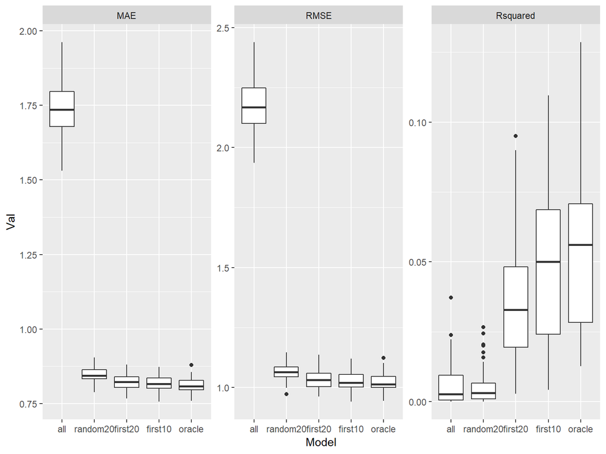

```r
# Setup fit control
fit.control <- trainControl(method = "repeatedcv", number = 5, repeats = 10)

# Formulas for models using first 10, 20 predictors
mod10 <- formula(y ~ X1 + X2 + X3 + X4 + X5 + X6 + X7 + X8 + X9 + X10)
mod20 <- formula(y ~ X1 + X2 + X3 + X4 + X5 + X6 + X7 + X8 + X9 + X10 + X11 + X12 + X13 + X14 + X15 + X16 + X17 + X18 + X19 + X20)

# How about a 20 randomly chosen predictors?
set.seed(123)
modrand20 <- as.formula(paste0("y ~ ", paste0("X", sample(1:600,size = 20), collapse = " + ")))

# Four different linear models
set.seed(123)
fit.all <- train(y ~ ., data = data.frame(y = y, X), trControl = fit.control, method = "lm")
set.seed(123)
fit.random20 <- train(modrand20, data = data.frame(y = y, X), trControl = fit.control, method = "lm")
set.seed(123)
fit.first20 <- train(mod20, data = data.frame(y = y, X), trControl = fit.control, method = "lm")
set.seed(123)
fit.first10 <- train(mod10, data = data.frame(y = y, X), trControl = fit.control, method = "lm")
set.seed(123)
fit.oracle <- train(y ~ X1 + X2, data = data.frame(y = y, X), trControl = fit.control, method = "lm")

# Compare their cv-estimated performance
resamps <- resamples(list(all = fit.all, random20 = fit.random20, first20 = fit.first20,  first10 = fit.first10, oracle = fit.oracle))

# Process the resamples results for visualization
resamps2 <- gather(resamps$values, key = "Var", value = "Val", 2:ncol(resamps$values))
resamps2 <- separate(resamps2, col = "Var", into = c("Model", "Metric"), sep = "~")
resamps2$Model <- factor(resamps2$Model, levels = c("all", "random20", "first20", "first10", "oracle"))

# The logistic regression model (LREG) has the best AUC, but it's sensitivity isn't good...
ggplot(resamps2, aes(x = Model, y = Val)) + geom_boxplot() + facet_wrap(~ Metric, scales = "free")
```

## How to choose subsets of predictors?

- Blindly using all 600 predictors doesn’t work very well, so do we make the problem manageable?
  - In the coming weeks, we will discuss a few automated approaches to variable selection (variable selection algorithms and penalized regression)
  - Automated approaches aren’t a cure-all, oftentimes the best approach is apply content area knowledge and use residuals plots, but in many situations there is too much data to not also use some automation to streamline the process

## Prediction Surfaces and Residual Plots

[Demonstrated with an RShiny App](https://remiller1450.github.io/s230s19/app.R)